# Taller de Análisis Exploratorio de Datos (EDA)

Predicción del Rendimiento Académico Estudiantil

Kendall Solano y Andrey Calderon

2025-12-11

# 1 Introducción al Taller

## 1.1 Objetivo General

En este taller práctico, se trabajará con un conjunto de datos real que contiene registros académicos de 2000 estudiantes. El objetivo es realizar un **Análisis Exploratorio de Datos (EDA)** utilizando R Studio, desde la importación de datos hasta la construcción de un modelo de regresión lineal simple.

## 1.2 ¿Qué es el EDA?

El **Análisis Exploratorio de Datos (EDA)** es el proceso de examinar y resumir las características principales de un conjunto de datos. Sus objetivos son:

- Comprender la estructura y contenido de los datos
- Detectar errores, valores faltantes o atípicos
- Calcular estadísticas descriptivas (media, mediana, moda, etc.)
- Visualizar patrones mediante gráficos
- Verificar supuestos estadísticos (como la normalidad)
- Identificar relaciones entre variables

# 2 Configuración del Entorno

```r
# Instalar paquetes si es necesario (descomentar si es primera vez)
# install.packages("ggplot2")
# install.packages("dplyr")
# install.packages("corrplot")
# install.packages("reshape2")

# Cargar librerías
library(ggplot2)
library(dplyr)
library(corrplot)
library(reshape2)

# Mostrar números sin notación científica
options(scipen = 999)
```

## 2.1 Importar el Dataset

```r
# Importar el dataset
# NOTA: Ajustar la ruta según la ubicación del archivo
datos <- read.csv("C:\\Users\\andre\\Documents\\CUATRIMESTRE_3_2025\\Big_Data\\Introduccion_Estadistica\\Repositorios\\Calificaciones(1).csv")

# Verificar que se cargó correctamente
cat("El dataset tiene", nrow(datos), "filas y", ncol(datos), "columnas\n")
```

```
## El dataset tiene 2000 filas y 7 columnas
```

**Respuesta:**

- Número de filas: 2000
- Número de columnas: 7

# 3 Exploración Inicial de los Datos

## 3.1 Primeras y Últimas Filas

```r
# Ver las primeras 6 filas
head(datos)
```

```
##   Student_ID Attendance.... Internal.Test.1..out.of.40.
## 1      S1000             84                          30
## 2      S1001             91                          24
## 3      S1002             73                          29
## 4      S1003             80                          36
## 5      S1004             84                          31
## 6      S1005            100                          34
##   Internal.Test.2..out.of.40. Assignment.Score..out.of.10. Daily.Study.Hours
## 1                          36                            7                 3
## 2                          38                            6                 3
## 3                          26                            7                 3
## 4                          35                            7                 3
## 5                          37                            8                 3
## 6                          34                            7                 3
##   Final.Exam.Marks..out.of.100.
## 1                            72
## 2                            56
## 3                            56
## 4                            74
## 5                            66
## 6                            79
```

```r
# Ver las últimas 6 filas
tail(datos)
```

```
##      Student_ID Attendance.... Internal.Test.1..out.of.40.
## 1995      S2994             97                          40
## 1996      S2995             82                          31
## 1997      S2996             78                          38
## 1998      S2997             78                          30
## 1999      S2998             82                          29
## 2000      S2999             97                          32
##      Internal.Test.2..out.of.40. Assignment.Score..out.of.10. Daily.Study.Hours
## 1995                          38                            9                 4
## 1996                          28                            6                 2
## 1997                          27                            7                 2
## 1998                          33                            9                 2
## 1999                          40                            8                 3
## 2000                          38                            7                 3
##      Final.Exam.Marks..out.of.100.
## 1995                            81
## 1996                            52
## 1997                            57
## 1998                            61
## 1999                            59
## 2000                            64
```

## 3.2 Estructura del Dataset

```r
# Ver estructura: tipos de variables
str(datos)
```

```
## 'data.frame':    2000 obs. of  7 variables:
##  $ Student_ID                   : chr  "S1000" "S1001" "S1002" "S1003" ...
##  $ Attendance....               : int  84 91 73 80 84 100 96 83 91 87 ...
##  $ Internal.Test.1..out.of.40.  : int  30 24 29 36 31 34 40 39 30 27 ...
##  $ Internal.Test.2..out.of.40.  : int  36 38 26 35 37 34 36 37 37 37 ...
##  $ Assignment.Score..out.of.10. : int  7 6 7 7 8 7 8 7 8 8 ...
##  $ Daily.Study.Hours            : int  3 3 3 3 3 3 3 3 2 3 ...
##  $ Final.Exam.Marks..out.of.100.: int  72 56 56 74 66 79 83 77 71 61 ...
```

```r
# Ver nombres de las columnas
names(datos)
```

```
## [1] "Student_ID"                    "Attendance...."
## [3] "Internal.Test.1..out.of.40."   "Internal.Test.2..out.of.40."
## [5] "Assignment.Score..out.of.10."  "Daily.Study.Hours"
## [7] "Final.Exam.Marks..out.of.100."
```

**Respuesta:**

1. Variables numericas: 6
2. Variables de texto: 1

## 3.3 Resumen Estadístico

```r
# Resumen de todas las variables
summary(datos)
```

```
##   Student_ID        Attendance....   Internal.Test.1..out.of.40.
##  Length:2000        Min.   : 52.00   Min.   :18.00
##  Class :character   1st Qu.: 80.00   1st Qu.:29.00
##  Mode  :character   Median : 85.00   Median :32.00
##                     Mean   : 84.89   Mean   :32.12
##                     3rd Qu.: 90.00   3rd Qu.:35.00
##                     Max.   :100.00   Max.   :40.00
##  Internal.Test.2..out.of.40. Assignment.Score..out.of.10. Daily.Study.Hours
##  Min.   :16.00               Min.   : 4.000               Min.   :1.000
##  1st Qu.:29.00               1st Qu.: 7.000               1st Qu.:2.000
##  Median :33.00               Median : 8.000               Median :3.000
##  Mean   :32.46               Mean   : 7.507               Mean   :2.824
##  3rd Qu.:36.00               3rd Qu.: 8.000               3rd Qu.:3.000
##  Max.   :40.00               Max.   :10.000               Max.   :5.000
##  Final.Exam.Marks..out.of.100.
##  Min.   : 25.00
##  1st Qu.: 58.00
##  Median : 65.00
##  Mean   : 64.86
##  3rd Qu.: 73.00
##  Max.   :100.00
```

**Respuesta:**

Minimo: 25

Maximo: 100

Mediana: 65

Media: 64.86

# 4 Limpieza y Preparación de Datos

## 4.1 Renombrar Columnas

```r
# Ver nombres actuales
names(datos)
```

```
## [1] "Student_ID"                    "Attendance...."
## [3] "Internal.Test.1..out.of.40."   "Internal.Test.2..out.of.40."
## [5] "Assignment.Score..out.of.10."  "Daily.Study.Hours"
## [7] "Final.Exam.Marks..out.of.100."
```

```r
# Renombrar las columnas a español
colnames(datos) <- c(
  "ID",                  # Student_ID
  "Asistencia",         # Attendance (%)
  "Examen_Interno_1",   # Internal Test 1 (out of 40)
  "Examen_Interno_2",   # Internal Test 2 (out of 40)
  "Promedio_Tareas",    # Assignment Score (out of 10)
  "Horas_Estudio",      # Daily Study Hours
  "Nota_Final"          # Final Exam Marks (out of 100)
)

# Verificar los nuevos nombres
names(datos)
```

```
## [1] "ID"               "Asistencia"       "Examen_Interno_1" "Examen_Interno_2"
## [5] "Promedio_Tareas"  "Horas_Estudio"    "Nota_Final"
```

## 4.2 Verificar Valores Faltantes

```r
# Contar valores NA en cada columna
colSums(is.na(datos))
```

```
##               ID       Asistencia Examen_Interno_1 Examen_Interno_2
##                0                0                0                0
##  Promedio_Tareas    Horas_Estudio       Nota_Final
##                0                0                0
```

```r
# Total de valores faltantes
cat("Total de valores faltantes:", sum(is.na(datos)), "\n")
```

```
## Total de valores faltantes: 0
```

**Respuesta:** ¿Existen valores faltantes? No

# 5 Estadística Descriptiva: Nota del Examen Final

## 5.1 Medidas de Tendencia Central

```r
# MEDIA (promedio)
media <- mean(datos$Nota_Final)
cat("Media:", round(media, 2), "\n")
```

```
## Media: 64.86
```

```r
# MEDIANA (valor central)
mediana <- median(datos$Nota_Final)
cat("Mediana:", round(mediana, 2), "\n")
```

```
## Mediana: 65
```

```r
# MODA (valor más frecuente)
tabla_freq <- table(round(datos$Nota_Final, 0))
moda <- as.numeric(names(tabla_freq)[which.max(tabla_freq)])
cat("Moda:", moda, "\n")
```

```
## Moda: 66
```

**Resumen:**

- Media: 64.86
- Mediana: 65
- Moda: 66

## 5.2 Medidas de Dispersión

```r
# VARIANZA
varianza <- var(datos$Nota_Final)
cat("Varianza:", round(varianza, 2), "\n")
```

```
## Varianza: 128.62
```

```r
# DESVIACIÓN ESTÁNDAR
desv_est <- sd(datos$Nota_Final)
cat("Desviación Estándar:", round(desv_est, 2), "\n")
```

```
## Desviación Estándar: 11.34
```

```r
# CUARTILES
cuartiles <- quantile(datos$Nota_Final, probs = c(0.25, 0.50, 0.75))
cat("Q1 (25%):", round(cuartiles[1], 2), "\n")
```

```
## Q1 (25%): 58
```

```r
cat("Q2 (50%):", round(cuartiles[2], 2), "\n")
```

```
## Q2 (50%): 65
```

```r
cat("Q3 (75%):", round(cuartiles[3], 2), "\n")
```

```
## Q3 (75%): 73
```

```r
# RANGO
rango <- max(datos$Nota_Final) - min(datos$Nota_Final)
cat("Rango:", round(rango, 2), "\n")
```

```
## Rango: 75
```

**Resumen:**

- Varianza: 128.62
- Desviacion Estandar: 11.34
- Cuartiles: Q1=58 Q2=65 Q3=73
- Rango: 75

# 6 Visualización de Datos

## 6.1 Gráfico de Pastel: Categorías de Rendimiento

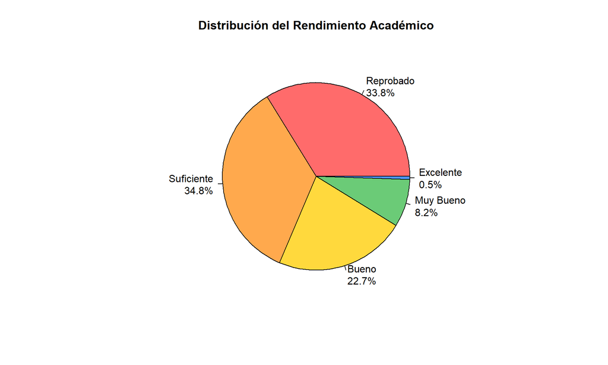

```r
# Crear categorías de rendimiento
datos$Rendimiento <- cut(datos$Nota_Final,
  breaks = c(0, 60, 70, 80, 90, 100),
  labels = c("Reprobado", "Suficiente", "Bueno", "Muy Bueno", "Excelente"),
  include.lowest = TRUE
)

# Contar estudiantes por categoría
frecuencias <- table(datos$Rendimiento)
porcentajes <- round(prop.table(frecuencias) * 100, 1)

# Crear etiquetas con porcentajes
etiquetas <- paste(names(frecuencias), "\n", porcentajes, "%", sep = "")

# Definir colores
colores <- c("#FF6B6B", "#FFA94D", "#FFD93D", "#6BCB77", "#4D96FF")

# Crear gráfico de pastel
pie(frecuencias,
    labels = etiquetas,
    col = colores,
    main = "Distribución del Rendimiento Académico")
```

**Resumen:**

- ¿Cual es la categoria con mas estudiantes? Suficiente
- ¿Que porcentaje de estudiantes reprobo? 33.8%

## 6.2 Diagrama de Barras: Nivel de Asistencia

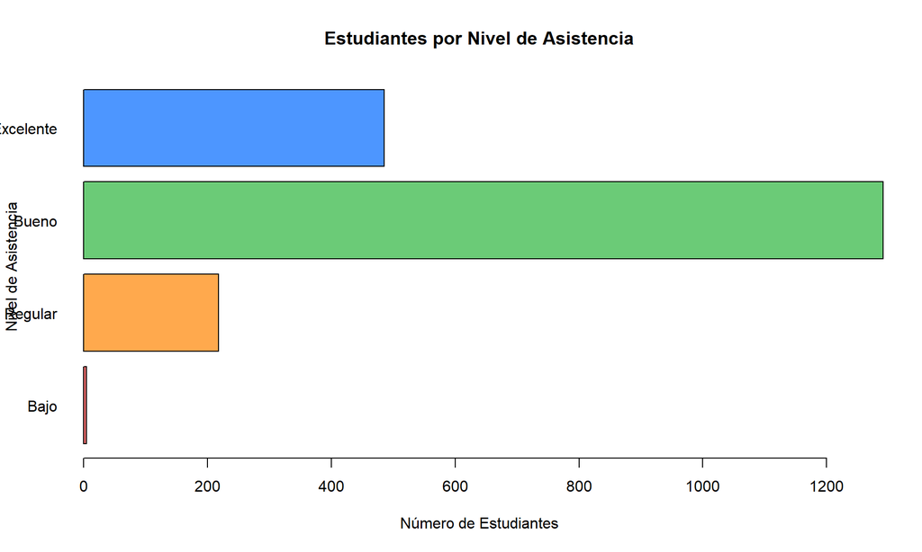

```r
# 7.2 Diagrama de barras horizontales: nivel de asistencia
datos$Nivel_Asistencia <- cut(
  datos$Asistencia,
  breaks = c(0, 60, 75, 90, 100),
  labels = c("Bajo", "Regular", "Bueno", "Excelente"),
  include.lowest = TRUE
)

# Tabla de frecuencias por nivel
freq_asistencia <- table(datos$Nivel_Asistencia)

# ---- GRÁFICO ----
barplot(
  freq_asistencia,
  horiz = TRUE,
  col   = c("#FF6B6B", "#FFA94D", "#6BCB77", "#4D96FF"),
  main  = "Estudiantes por Nivel de Asistencia",
  xlab  = "Número de Estudiantes",
  ylab  = "Nivel de Asistencia",
  las   = 1
)
```

```r
cat("\nFrecuencias por nivel de asistencia:\n")
```

```
##
## Frecuencias por nivel de asistencia:
```

```r
print(freq_asistencia)
```

```
##
##      Bajo   Regular     Bueno Excelente
##         5       218      1291       486
```

**Respuestas:**

- ¿Cuantos estudiantes tienen asistencia “Excelente”? 486
- ¿Cual nivel de asistencia tiene menos estudiantes? Bajo con 5

## 6.3 Diagrama de Cajas: Exámenes Internos

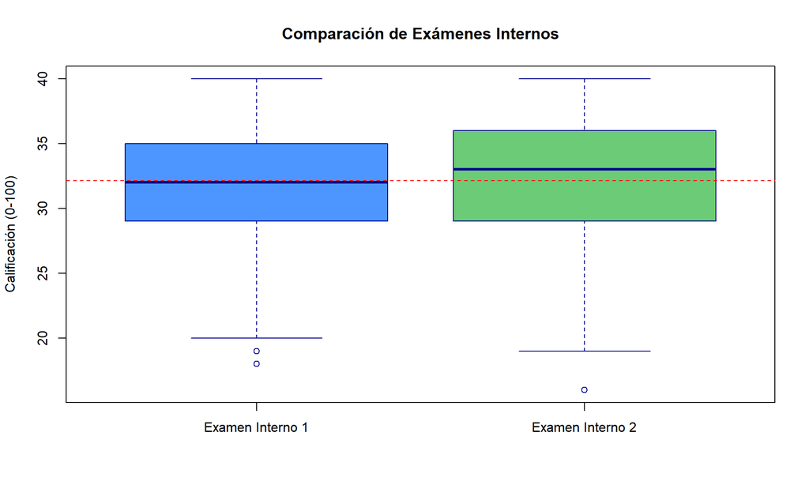

```r
# Crear diagrama de cajas
boxplot(datos$Examen_Interno_1, datos$Examen_Interno_2,
        names = c("Examen Interno 1", "Examen Interno 2"),
        col = c("#4D96FF", "#6BCB77"),
        main = "Comparación de Exámenes Internos",
        ylab = "Calificación (0-100)",
        border = "darkblue")

# Agregar línea de la media
abline(h = mean(datos$Examen_Interno_1), col = "red", lty = 2)
```

```r
# Estadísticas
cat("=== EXAMEN INTERNO 1 ===\n")
```

```
## === EXAMEN INTERNO 1 ===
```

```r
cat("Media:", round(mean(datos$Examen_Interno_1), 2), "\n")
```

```
## Media: 32.12
```

```r
cat("Mediana:", round(median(datos$Examen_Interno_1), 2), "\n")
```

```
## Mediana: 32
```

```r
cat("Desv. Est.:", round(sd(datos$Examen_Interno_1), 2), "\n\n")
```

```
## Desv. Est.: 4.56
```

```r
cat("=== EXAMEN INTERNO 2 ===\n")
```

```
## === EXAMEN INTERNO 2 ===
```

```r
cat("Media:", round(mean(datos$Examen_Interno_2), 2), "\n")
```

```
## Media: 32.46
```

```r
cat("Mediana:", round(median(datos$Examen_Interno_2), 2), "\n")
```

```
## Mediana: 33
```

```r
cat("Desv. Est.:", round(sd(datos$Examen_Interno_2), 2), "\n")
```

```
## Desv. Est.: 4.52
```

**Respuestas:**

- Examen con mediana mas alta: Examen Interno 2
- Examen con mayor dispersion: Examen Interno 1
- ¿Existen valores atipicos? Si 2 en examen interno 1 y 1 en exament interno 2

## 6.4 Gráfico de Violín: Nota Final por Nivel de Asistencia

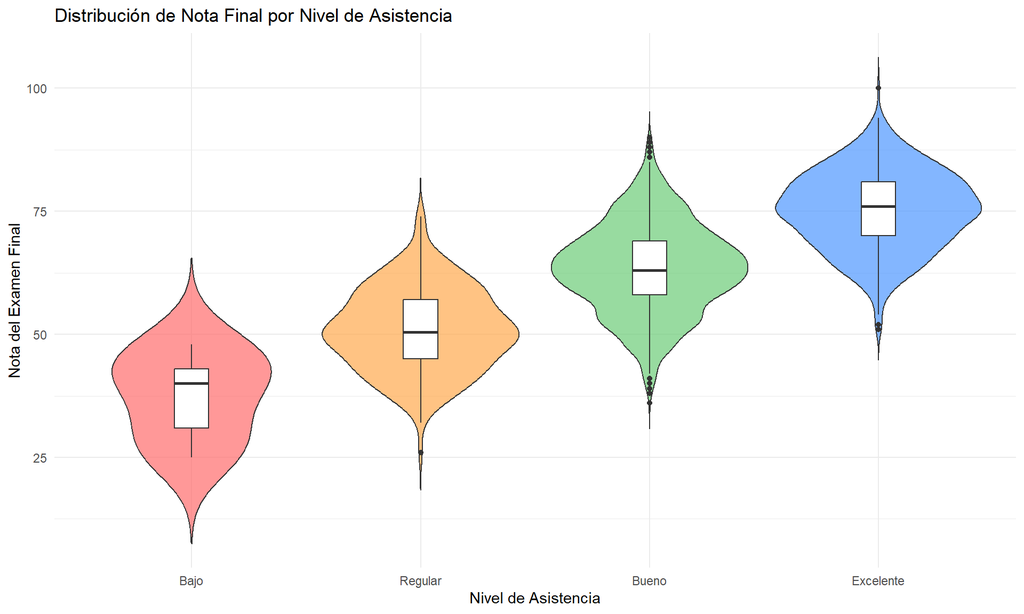

```r
ggplot(datos, aes(x = Nivel_Asistencia, y = Nota_Final, fill = Nivel_Asistencia)) +
  geom_violin(trim = FALSE, alpha = 0.7) +
  geom_boxplot(width = 0.15, fill = "white") +
  scale_fill_manual(values = c("#FF6B6B", "#FFA94D", "#6BCB77", "#4D96FF")) +
  labs(
    title = "Distribución de Nota Final por Nivel de Asistencia",
    x = "Nivel de Asistencia",
    y = "Nota del Examen Final"
  ) +
  theme_minimal() +
  theme(legend.position = "none")
```

**Respuestas** - Nivel con notas mas altas: Exelente - Diferencias en las distribuciones: Los estudiantes con mejores notas contiene mejores notas, nos da a entedenter que hay una correlacion positiva —

# 7 Análisis de Normalidad

## 7.1 Histograma con Curva Normal

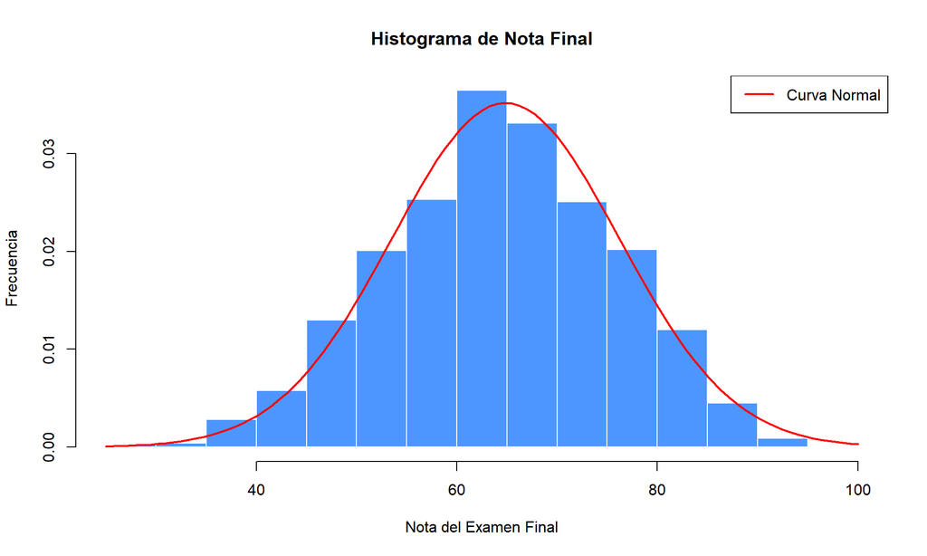

```r
# Crear histograma
hist(datos$Nota_Final,
     breaks = 20,
     col = "#4D96FF",
     border = "white",
     main = "Histograma de Nota Final",
     xlab = "Nota del Examen Final",
     ylab = "Frecuencia",
     freq = FALSE)

# Agregar curva normal teórica
curve(dnorm(x, mean = mean(datos$Nota_Final), sd = sd(datos$Nota_Final)),
      add = TRUE,
      col = "red",
      lwd = 2)

# Agregar leyenda
legend("topright",
       legend = "Curva Normal",
       col = "red",
       lwd = 2)
```

## 7.2 Gráfico Q-Q

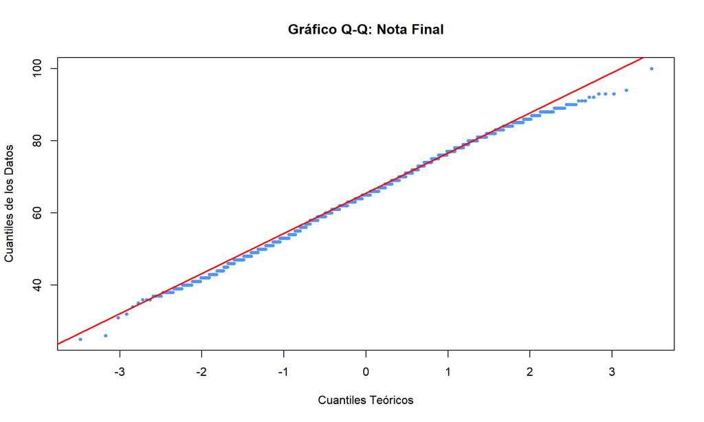

```r
# Crear gráfico Q-Q
qqnorm(datos$Nota_Final,
       main = "Gráfico Q-Q: Nota Final",
       xlab = "Cuantiles Teóricos",
       ylab = "Cuantiles de los Datos",
       col = "#4D96FF",
       pch = 19,
       cex = 0.6)

# Agregar línea de referencia
qqline(datos$Nota_Final, col = "red", lwd = 2)
```

**Respuestas**

- ¿Los puntos siguen la linea roja? Si
- ¿Existen desviaciones en los extremos? Si pero una muy leve al final

## 7.3 Pruebas Estadísticas de Normalidad

```r
# Prueba de Shapiro-Wilk
shapiro_test <- shapiro.test(datos$Nota_Final)

cat("=== PRUEBA DE SHAPIRO-WILK ===\n")
```

```
## === PRUEBA DE SHAPIRO-WILK ===
```

```r
cat("Estadístico W:", round(shapiro_test$statistic, 4), "\n")
```

```
## Estadístico W: 0.9966
```

```r
cat("Valor p:", shapiro_test$p.value, "\n")
```

```
## Valor p: 0.0002190907
```

```r
if(shapiro_test$p.value > 0.05) {
  cat("Conclusión: Los datos SON NORMALES (p > 0.05)\n\n")
} else {
  cat("Conclusión: Los datos NO SON NORMALES (p <= 0.05)\n\n")
}
```

```
## Conclusión: Los datos NO SON NORMALES (p <= 0.05)
```

```r
# Prueba de Kolmogorov-Smirnov
datos_std <- (datos$Nota_Final - mean(datos$Nota_Final)) / sd(datos$Nota_Final)
ks_test <- ks.test(datos_std, "pnorm")

cat("=== PRUEBA DE KOLMOGOROV-SMIRNOV ===\n")
```

```
## === PRUEBA DE KOLMOGOROV-SMIRNOV ===
```

```r
cat("Estadístico D:", round(ks_test$statistic, 4), "\n")
```

```
## Estadístico D: 0.029
```

```r
cat("Valor p:", ks_test$p.value, "\n")
```

```
## Valor p: 0.06953239
```

```r
if(ks_test$p.value > 0.05) {
  cat("Conclusión: Los datos SON NORMALES (p > 0.05)\n")
} else {
  cat("Conclusión: Los datos NO SON NORMALES (p <= 0.05)\n")
}
```

```
## Conclusión: Los datos SON NORMALES (p > 0.05)
```

**Respuesta**

- Prueba de Shapiro-Wilk: Valor p = 0.0002190907 Conclusion: NO SON NORMALES
- Prueba de Kolmogorov-Smirnov: Valor p = 0.06953239 Conclusion: SON NORMALES
- ¿Los datos de Nota Final son normales? Segun la prueba Shapiro-Wilk no lo son pero segun Smirnov si

# 8 Análisis de Correlación

## 8.1 Mapa de Calor de Correlaciones

```r
# Seleccionar solo variables numéricas
vars_numericas <- datos[, c("Asistencia", "Examen_Interno_1",
                            "Examen_Interno_2", "Promedio_Tareas",
                            "Horas_Estudio", "Nota_Final")]

# Calcular matriz de correlación
matriz_cor <- cor(vars_numericas)

# Mostrar la matriz
round(matriz_cor, 2)
```

```
##                  Asistencia Examen_Interno_1 Examen_Interno_2 Promedio_Tareas
## Asistencia             1.00             0.51             0.49            0.43
## Examen_Interno_1       0.51             1.00             0.26            0.57
## Examen_Interno_2       0.49             0.26             1.00            0.54
## Promedio_Tareas        0.43             0.57             0.54            1.00
## Horas_Estudio          0.30             0.21             0.23            0.17
## Nota_Final             0.73             0.69             0.69            0.67
##                  Horas_Estudio Nota_Final
## Asistencia                0.30       0.73
## Examen_Interno_1          0.21       0.69
## Examen_Interno_2          0.23       0.69
## Promedio_Tareas           0.17       0.67
## Horas_Estudio             1.00       0.41
## Nota_Final                0.41       1.00
```

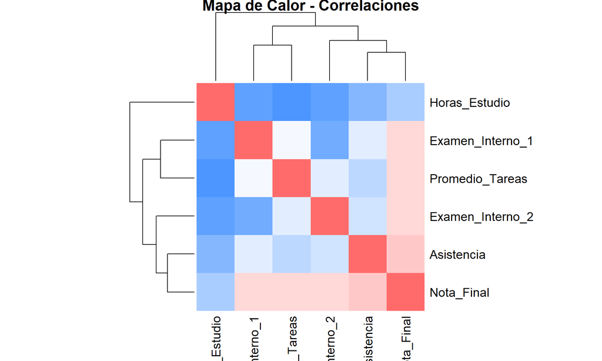

```r
############################################################
# --- 9.1 HEATMAP ---
############################################################

heatmap(
  matriz_cor,
  col = colorRampPalette(c("#4D96FF", "white", "#FF6B6B"))(20),
  symm = TRUE,
  main = "Mapa de Calor - Correlaciones"
)
```

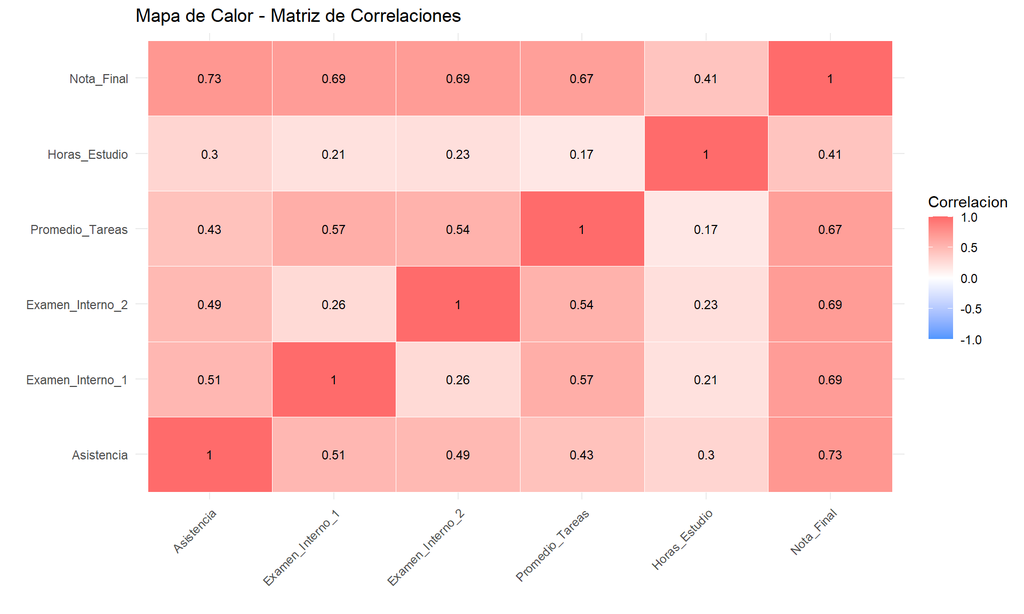

```r
############################################################
# --- HEATMAP CON GGPLOT ---
############################################################

library(reshape2)
library(ggplot2)

# Convertir matriz a formato largo
matriz_largo <- melt(matriz_cor)
colnames(matriz_largo) <- c("Variable1", "Variable2", "Correlacion")

ggplot(matriz_largo, aes(x = Variable1, y = Variable2, fill = Correlacion)) +
  geom_tile(color = "white") +
  geom_text(aes(label = round(Correlacion, 2)), size = 3) +
  scale_fill_gradient2(
    low = "#4D96FF",
    mid = "white",
    high = "#FF6B6B",
    midpoint = 0,
    limit = c(-1, 1)
  ) +
  labs(
    title = "Mapa de Calor - Matriz de Correlaciones",
    x = "",
    y = ""
  ) +
  theme_minimal() +
  theme(axis.text.x = element_text(angle = 45, hjust = 1))
```

**Respuestas:**

- Variables con correlacion mas fuerte: Nota final y asistecia con R= 0,726
- ¿Existe correlacion negativa? No, no existe ninguna correlación negativa
- Variable mas correlacionada con Nota Final: Asistencia con r = 0.726

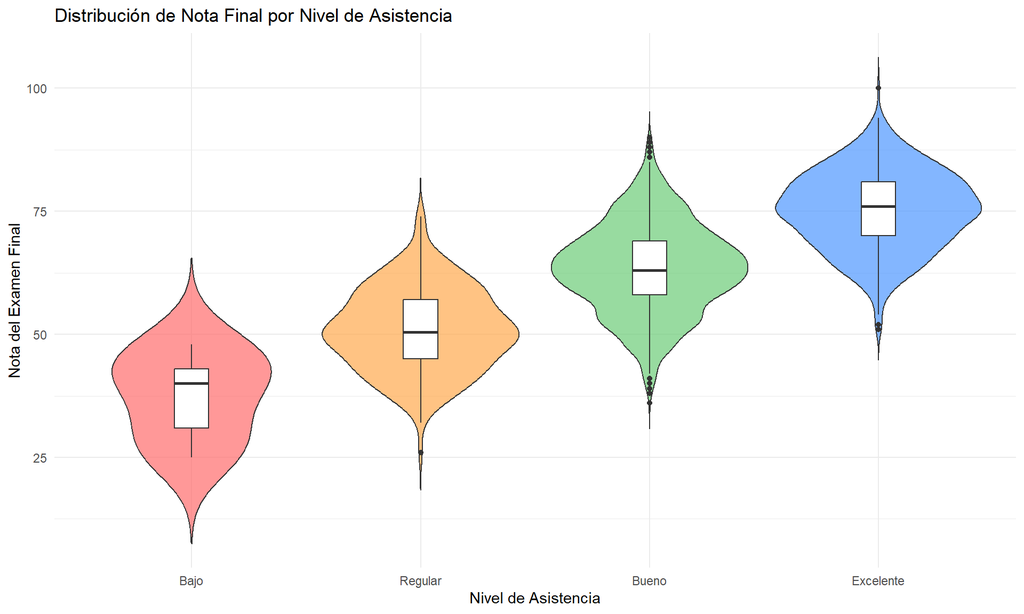

```r
ggplot(datos, aes(x = Nivel_Asistencia, y = Nota_Final, fill = Nivel_Asistencia)) +
  geom_violin(trim = FALSE, alpha = 0.7) +
  geom_boxplot(width = 0.15, fill = "white") +
  scale_fill_manual(values = c("#FF6B6B", "#FFA94D", "#6BCB77", "#4D96FF")) +
  labs(
    title = "Distribución de Nota Final por Nivel de Asistencia",
    x = "Nivel de Asistencia",
    y = "Nota del Examen Final"
  ) +
  theme_minimal() +
  theme(legend.position = "none")
```

**Respuestas:**

# 9 Analisis de correlacion

## 9.1 Mapa de calor

```r
############################################################
# --- 9+.1 MAPA DE CALOR DE CORRELACIONES ---
############################################################

# Seleccionar variables numéricas
vars_numericas <- datos[, c(
  "Asistencia",
  "Examen_Interno_1",
  "Examen_Interno_2",
  "Promedio_Tareas",
  "Horas_Estudio",
  "Nota_Final"
)]

# Matriz de correlación
matriz_cor <- cor(vars_numericas)

# Mostrar matriz redondeada
round(matriz_cor, 2)
```

```
##                  Asistencia Examen_Interno_1 Examen_Interno_2 Promedio_Tareas
## Asistencia             1.00             0.51             0.49            0.43
## Examen_Interno_1       0.51             1.00             0.26            0.57
## Examen_Interno_2       0.49             0.26             1.00            0.54
## Promedio_Tareas        0.43             0.57             0.54            1.00
## Horas_Estudio          0.30             0.21             0.23            0.17
## Nota_Final             0.73             0.69             0.69            0.67
##                  Horas_Estudio Nota_Final
## Asistencia                0.30       0.73
## Examen_Interno_1          0.21       0.69
## Examen_Interno_2          0.23       0.69
## Promedio_Tareas           0.17       0.67
## Horas_Estudio             1.00       0.41
## Nota_Final                0.41       1.00
```

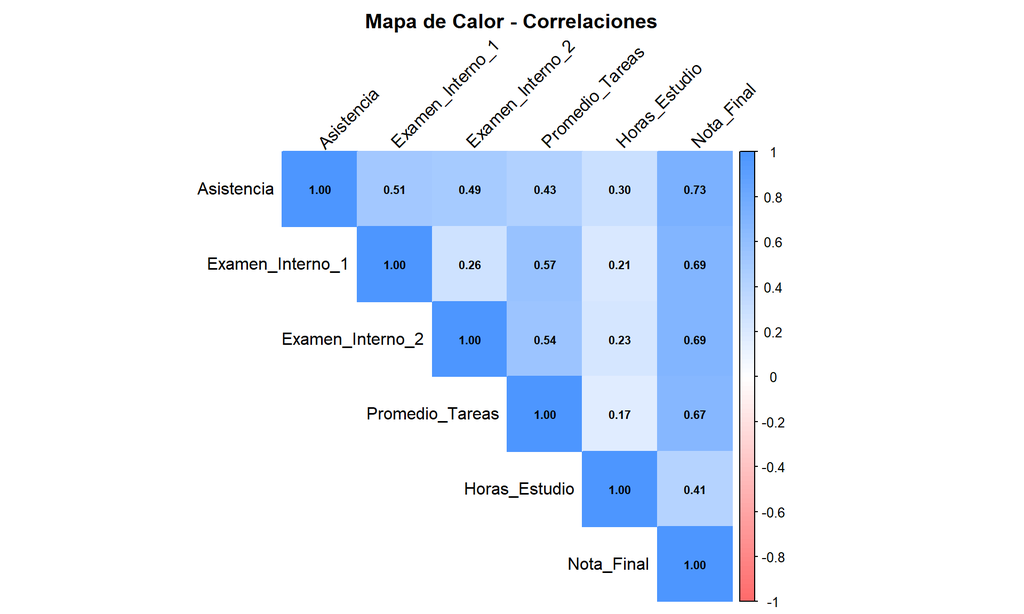

```r
# Mapa de calor con corrplot
corrplot(
  matriz_cor,
  method = "color",
  type = "upper",
  addCoef.col = "black",
  number.cex = 0.7,
  tl.col = "black",
  tl.srt = 45,
  col = colorRampPalette(c("#FF6B6B", "white", "#4D96FF"))(100),
  title = "Mapa de Calor - Correlaciones",
  mar = c(0, 0, 2, 0)
)
```

## 9.2 Gráfico de Dispersión: Asistencia vs Nota Final

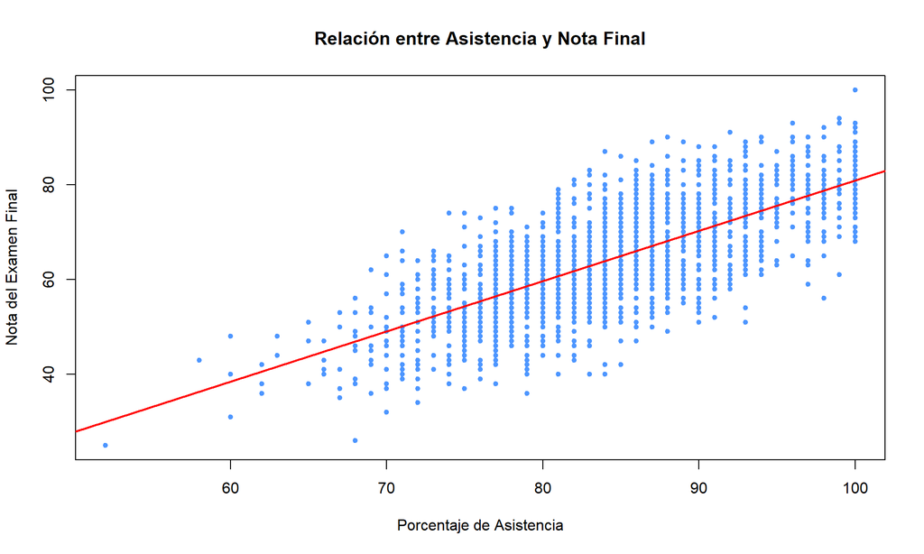

```r
# Crear gráfico de dispersión
plot(datos$Asistencia, datos$Nota_Final,
     main = "Relación entre Asistencia y Nota Final",
     xlab = "Porcentaje de Asistencia",
     ylab = "Nota del Examen Final",
     col = "#4D96FF",
     pch = 19,
     cex = 0.7)

# Agregar línea de tendencia
abline(lm(Nota_Final ~ Asistencia, data = datos),
       col = "red",
       lwd = 2)
```

## 9.3 Correlación de Pearson

```r
# Calcular correlación
correlacion <- cor(datos$Asistencia, datos$Nota_Final)
cat("Coeficiente de correlación (r):", round(correlacion, 4), "\n")
```

```
## Coeficiente de correlación (r): 0.7256
```

```r
# Prueba de significancia
prueba_cor <- cor.test(datos$Asistencia, datos$Nota_Final)
cat("Valor p:", prueba_cor$p.value, "\n")
```

```
## Valor p: 0
```

```r
if(prueba_cor$p.value < 0.05) {
  cat("La correlación ES estadísticamente significativa\n")
} else {
  cat("La correlación NO es significativa\n")
}
```

```
## La correlación ES estadísticamente significativa
```

**Respuestas:**

- Coeficiente r = 0.7256
- Valor p = 0
- Tipo de correlacion (fuerte/moderada/debil): Fuerte
- ¿Es significativa? (Si / No): Si

# 10 Regresión Lineal Simple

## 10.1 Crear el Modelo

```r
# Crear modelo
modelo <- lm(Nota_Final ~ Asistencia, data = datos)

# Ver resumen
summary(modelo)
```

```
##
## Call:
## lm(formula = Nota_Final ~ Asistencia, data = datos)
##
## Residuals:
##      Min       1Q   Median       3Q      Max
## -23.9094  -5.4021   0.1196   5.4230  23.0906
##
## Coefficients:
##             Estimate Std. Error t value            Pr(>|t|)
## (Intercept) -25.1883     1.9181  -13.13 <0.0000000000000002 ***
## Asistencia    1.0607     0.0225   47.14 <0.0000000000000002 ***
## ---
## Signif. codes:  0 '***' 0.001 '**' 0.01 '*' 0.05 '.' 0.1 ' ' 1
##
## Residual standard error: 7.806 on 1998 degrees of freedom
## Multiple R-squared:  0.5266, Adjusted R-squared:  0.5263
## F-statistic:  2222 on 1 and 1998 DF,  p-value: < 0.00000000000000022
```

## 10.2 Interpretar Resultados

```r
# Obtener coeficientes
intercepto <- coef(modelo)[1]
pendiente <- coef(modelo)[2]

cat("=== ECUACIÓN DEL MODELO ===\n")
```

```
## === ECUACIÓN DEL MODELO ===
```

```r
cat("Nota_Final =", round(intercepto, 2), "+",
    round(pendiente, 2), "* Asistencia\n\n")
```

```
## Nota_Final = -25.19 + 1.06 * Asistencia
```

```r
# Coeficiente de determinación R²
r_cuadrado <- summary(modelo)$r.squared
cat("R cuadrado (R²):", round(r_cuadrado, 4), "\n")
```

```
## R cuadrado (R²): 0.5266
```

```r
cat("La Asistencia explica el", round(r_cuadrado * 100, 1),
    "% de la variabilidad en la Nota Final\n")
```

```
## La Asistencia explica el 52.7 % de la variabilidad en la Nota Final
```

**respuestas:**

- Nota_Final = -25.19 + 1.06 × Asistencia
- R² = 0.5266
- Interpretación: La Asistencia explica el 52.7% de la variabilidad en la nota final.

## 10.3 Visualizar el Modelo

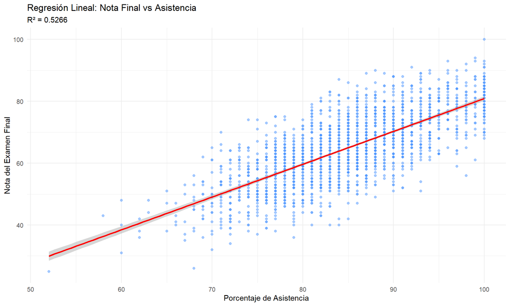

```r
ggplot(datos, aes(x = Asistencia, y = Nota_Final)) +
  geom_point(color = "#4D96FF", alpha = 0.5) +
  geom_smooth(method = "lm", color = "red", se = TRUE) +
  labs(
    title = "Regresión Lineal: Nota Final vs Asistencia",
    subtitle = paste("R² =", round(r_cuadrado, 4)),
    x = "Porcentaje de Asistencia",
    y = "Nota del Examen Final"
  ) +
  theme_minimal()
```

## 10.4 Realizar Predicciones

```r
# Crear datos para predicción
nuevos_datos <- data.frame(Asistencia = c(60, 70, 80, 85, 90, 100))

# Realizar predicciones
predicciones <- predict(modelo, newdata = nuevos_datos)

# Mostrar resultados
cat("=== PREDICCIONES ===\n")
```

```
## === PREDICCIONES ===
```

```r
for(i in 1:length(nuevos_datos$Asistencia)) {
  cat("Asistencia:", nuevos_datos$Asistencia[i],
      "% -> Nota predicha:", round(predicciones[i], 1), "\n")
}
```

```
## Asistencia: 60 % -> Nota predicha: 38.5
## Asistencia: 70 % -> Nota predicha: 49.1
## Asistencia: 80 % -> Nota predicha: 59.7
## Asistencia: 85 % -> Nota predicha: 65
## Asistencia: 90 % -> Nota predicha: 70.3
## Asistencia: 100 % -> Nota predicha: 80.9
```

**respuesta:**

- Nota Final predicha = 65

# 11 Conclusiones

## 11.2 Recomendaciones

Basándose en el análisis realizado:

- La asistencia a clases tiene un impacto significativo en el rendimiento académico
- Se recomienda mantener un nivel de asistencia superior al 80% para optimizar el rendimiento
- Los estudiantes deben ser conscientes de que cada clase a la que asisten contribuye positivamente a su nota final